# Projet d'Analyse de Données : prédire la survie des passagers durant le voyage du Titanic

### **Introduction**

**1. problème**

Le `15 avril 1912`, au cours de son voyage inaugural, le `Titanic` a coulé après avoir heurté un iceberg, tuant `1502` passagers et membres d’équipage sur `2224`. `Taux de survie traduit de 32 %`. L’une des raisons pour lesquelles le naufrage a causé de telles pertes de vie, c’est qu’il n’y avait pas suffisamment d’embarcations de sauvetage pour les passagers et l’équipage. Bien qu’il y ait eu un certain facteur de chance dans la survie au naufrage, certains groupes de personnes étaient plus susceptibles de survivre que d’autres, comme `les femmes`, `les enfants` et `la classe supérieure`. Ainsi, le voyage du `Titanic` a généré beaucoup de `données` que les statisticiens ont collecté à fin de les `analyser` et les `mettre en valeur` pour prédire d'autres situations et éviter la répétition d'un tel problème .

**2. Le data set**

Le data set est composé de 12 colonnes et 418 lignes où 7 colonnes sont quantitatives et 5 qualitatives, il a comme valeurs nulles 414 répartis entre plusieurs colonnes

##### Une brève description de chaque colonne est la suivante :

· `PassengerId` - ID unique d'identification du passager · `Survived` - Drapeau de survie (0 = mort, 1 = survie) · `Pclass` - Classe de billet · `Name` - Nom du passager · `Sex` - Genre (homme = homme, femme = femme) · `Age` - Age · `SibSp` - Nombre de frères et sœurs / conjoints à bord du Titanic · `Parch` - Nombre de parents / enfants sur le Titanic · `Ticket` - Numéro de ticket · `Fare` - tarif · `Cabin` - Numéro de chambre · `Embarked` - Point de départ (port sur Titanic)

Nous allons également donner une brève description de chaque variable. pclass = classe de billet 1 = classe supérieure (riche) 2 = classe intermédiaire (classe générale) 3 = classe inférieure (classe ouvrière)

Embarked = La définition de chaque variable est la suivante C = Cherbourg Q = Queenstown S = Southampton NaN = représente une perte de données.

**3. Hypothèses et questions**

Je me souviens à peine quand j'ai regardé le film Titanic pour la première fois, mais Titanic reste toujours un sujet de discussion dans les domaines les plus divers. Ainsi plusieurs questions se pose à ce points :

- Quel genre de peuple survit ?
- Quels sont les facteurs influençant la survie des personnes ?
- L'age des personnes survis ?
- Quelle classe dominant les classes des survivants ?
- Peut on dire que les femmes et les enfants ont une forte chance à survivre ?

## **I. Exploration des données**

```python
#importer les packages
import pandas as pd
import numpy as np
import seaborn as sns
```

```python
#charger le dataset
data = pd.read_csv('tested.csv')
```

```python
#les types de données
data.dtypes
```

```
PassengerId      int64
Survived         int64
Pclass           int64
Name            object
Sex             object
Age            float64
SibSp            int64
Parch            int64
Ticket          object
Fare           float64
Cabin           object
Embarked        object
dtype: object
```

```python
#prévoir le format de donnée
data.shape
```

```
(418, 12)
```

```python
#lire les 5 premières lignes
data.head()
```

|  | PassengerId | Survived | Pclass | Name | Sex | Age | SibSp | Parch | Ticket | Fare | Cabin | Embarked |
| --- | --- | --- | --- | --- | --- | --- | --- | --- | --- | --- | --- | --- |
| 0 | 892 | 0 | 3 | Kelly, Mr. James | male | 34.5 | 0 | 0 | 330911 | 7.8292 | NaN | Q |
| 1 | 893 | 1 | 3 | Wilkes, Mrs. James (Ellen Needs) | female | 47.0 | 1 | 0 | 363272 | 7.0000 | NaN | S |
| 2 | 894 | 0 | 2 | Myles, Mr. Thomas Francis | male | 62.0 | 0 | 0 | 240276 | 9.6875 | NaN | Q |
| 3 | 895 | 0 | 3 | Wirz, Mr. Albert | male | 27.0 | 0 | 0 | 315154 | 8.6625 | NaN | S |
| 4 | 896 | 1 | 3 | Hirvonen, Mrs. Alexander (Helga E Lindqvist) | female | 22.0 | 1 | 1 | 3101298 | 12.2875 | NaN | S |

```python
# statistiques sur les données
data.describe()
```

|  | PassengerId | Survived | Pclass | Age | SibSp | Parch | Fare |
| --- | --- | --- | --- | --- | --- | --- | --- |
| count | 418.000000 | 418.000000 | 418.000000 | 332.000000 | 418.000000 | 418.000000 | 417.000000 |
| mean | 1100.500000 | 0.363636 | 2.265550 | 30.272590 | 0.447368 | 0.392344 | 35.627188 |
| std | 120.810458 | 0.481622 | 0.841838 | 14.181209 | 0.896760 | 0.981429 | 55.907576 |
| min | 892.000000 | 0.000000 | 1.000000 | 0.170000 | 0.000000 | 0.000000 | 0.000000 |
| 25% | 996.250000 | 0.000000 | 1.000000 | 21.000000 | 0.000000 | 0.000000 | 7.895800 |
| 50% | 1100.500000 | 0.000000 | 3.000000 | 27.000000 | 0.000000 | 0.000000 | 14.454200 |
| 75% | 1204.750000 | 1.000000 | 3.000000 | 39.000000 | 1.000000 | 0.000000 | 31.500000 |
| max | 1309.000000 | 1.000000 | 3.000000 | 76.000000 | 8.000000 | 9.000000 | 512.329200 |

## **II. Pre-traitement des données**

```python
#voir le nombre de valeurs nulles pour chaque colonne
data.isnull().sum().sum()
```

```
414
```

*=>* On peut constater que les trois colonnes `Age`,`Fare` et `Cabin` ont des valeurs nulles

```python
#voir le nombre total de valeurs nulles
data.isnull().sum()
```

```
PassengerId      0
Survived         0
Pclass           0
Name             0
Sex              0
Age             86
SibSp            0
Parch            0
Ticket           0
Fare             1
Cabin          327
Embarked         0
dtype: int64
```

*=>* Le nombre total des valeurs nulles est de `414`

- **On va procéder au traitement des données manquantes :**

```python
#Pour la colonne 'Fare'
data[data['Fare'].isnull()]
```

|  | PassengerId | Survived | Pclass | Name | Sex | Age | SibSp | Parch | Ticket | Fare | Cabin | Embarked |
| --- | --- | --- | --- | --- | --- | --- | --- | --- | --- | --- | --- | --- |
| 152 | 1044 | 0 | 3 | Storey, Mr. Thomas | male | 60.5 | 0 | 0 | 3701 | NaN | NaN | S |

*=>* Comme ce passager est de classe 3 on va remplacer la valeur manquante de colonne `Fare` par la `moyenne` des valeurs `Fare` des personnes de 3ème classe

```python
#la `moyenne` des valeurs `Fare` des personnes de 3ème classe
avg_fare_p3 = np.mean(data[data['Pclass'] == 3]['Fare'])
data['Fare'].fillna(avg_fare_p3 , inplace=True)
```

```python
#Vérification
data.loc[data['Fare'].isnull()]
```

|  | PassengerId | Survived | Pclass | Name | Sex | Age | SibSp | Parch | Ticket | Fare | Cabin | Embarked |
| --- | --- | --- | --- | --- | --- | --- | --- | --- | --- | --- | --- | --- |

```python
#Pour la colonne 'Age'
data[data['Age'].isnull()]
```

|  | PassengerId | Survived | Pclass | Name | Sex | Age | SibSp | Parch | Ticket | Fare | Cabin | Embarked |
| --- | --- | --- | --- | --- | --- | --- | --- | --- | --- | --- | --- | --- |
| 10 | 902 | 0 | 3 | Ilieff, Mr. Ylio | male | NaN | 0 | 0 | 349220 | 7.8958 | NaN | S |
| 22 | 914 | 1 | 1 | Flegenheim, Mrs. Alfred (Antoinette) | female | NaN | 0 | 0 | PC 17598 | 31.6833 | NaN | S |
| 29 | 921 | 0 | 3 | Samaan, Mr. Elias | male | NaN | 2 | 0 | 2662 | 21.6792 | NaN | C |
| 33 | 925 | 1 | 3 | Johnston, Mrs. Andrew G (Elizabeth Lily" Watson)" | female | NaN | 1 | 2 | W./C. 6607 | 23.4500 | NaN | S |
| 36 | 928 | 1 | 3 | Roth, Miss. Sarah A | female | NaN | 0 | 0 | 342712 | 8.0500 | NaN | S |
| ... | ... | ... | ... | ... | ... | ... | ... | ... | ... | ... | ... | ... |
| 408 | 1300 | 1 | 3 | Riordan, Miss. Johanna Hannah"" | female | NaN | 0 | 0 | 334915 | 7.7208 | NaN | Q |
| 410 | 1302 | 1 | 3 | Naughton, Miss. Hannah | female | NaN | 0 | 0 | 365237 | 7.7500 | NaN | Q |
| 413 | 1305 | 0 | 3 | Spector, Mr. Woolf | male | NaN | 0 | 0 | A.5. 3236 | 8.0500 | NaN | S |
| 416 | 1308 | 0 | 3 | Ware, Mr. Frederick | male | NaN | 0 | 0 | 359309 | 8.0500 | NaN | S |
| 417 | 1309 | 0 | 3 | Peter, Master. Michael J | male | NaN | 1 | 1 | 2668 | 22.3583 | NaN | C |

86 rows × 12 columns

*=>* Comme la colonne `Cabin` contient `327 valeur nulle` on va prendre une copie du dataset original(pour la préserver) et on travaille avec le dataset original où cette colonne sera supprimer

```python
#prendre une copie
copie_data = data.copy()
#supprimer la colonne non désirée
data.drop(['Cabin'] , axis=1 , inplace = True)
```

```python
#vérifier
data.head()
```

|  | PassengerId | Survived | Pclass | Name | Sex | Age | SibSp | Parch | Ticket | Fare | Embarked |
| --- | --- | --- | --- | --- | --- | --- | --- | --- | --- | --- | --- |
| 0 | 892 | 0 | 3 | Kelly, Mr. James | male | 34.5 | 0 | 0 | 330911 | 7.8292 | Q |
| 1 | 893 | 1 | 3 | Wilkes, Mrs. James (Ellen Needs) | female | 47.0 | 1 | 0 | 363272 | 7.0000 | S |
| 2 | 894 | 0 | 2 | Myles, Mr. Thomas Francis | male | 62.0 | 0 | 0 | 240276 | 9.6875 | Q |
| 3 | 895 | 0 | 3 | Wirz, Mr. Albert | male | 27.0 | 0 | 0 | 315154 | 8.6625 | S |
| 4 | 896 | 1 | 3 | Hirvonen, Mrs. Alexander (Helga E Lindqvist) | female | 22.0 | 1 | 1 | 3101298 | 12.2875 | S |

- **`Suppression` des valeurs manquantes de la colonne `Age`** :

```python
#l'ensemble des valeurs manquantes de la colonne age ne représente que 20%
np.round((data.isnull().sum()['Age']/data.shape[0])*100,2)
```

```
20.57
```

```python
# comme l'ensemble des valeurs manquantes de la colonne age ne représente que 20% de l'ensemble des valeurs
# on va supprimer cette tranche
data.drop(list(data[data['Age'].isnull()]['Age'].index) , axis = 0 , inplace=True)
```

```python
# rénitialiser les indices
data.reset_index(drop=True, inplace=True)
```

```python
# vérification
data.isnull().sum()
```

```
PassengerId    0
Survived       0
Pclass         0
Name           0
Sex            0
Age            0
SibSp          0
Parch          0
Ticket         0
Fare           0
Embarked       0
dtype: int64
```

```python
# savoir le nombre de lignes répétées
data.duplicated().sum()
```

```
0
```

*=>* On constate que le dataset `ne contient pas de valeurs répétées`

- **`Detection` des outliers** :
1. **Pour la variable `Age`** :

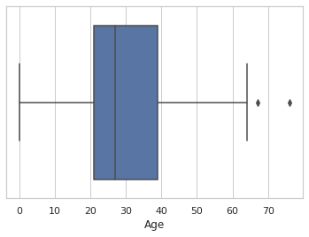

```python
# choisir le theme seaborn
sns.set_theme(style="whitegrid")
ax = sns.boxplot(x=data['Age'])
```

1. **Pour la variable `Fare`** :

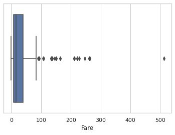

```python
# choisir le theme seaborn
sns.set_theme(style="whitegrid")
ax = sns.boxplot(x=data['Fare'])
```

*=>* La suppression des `outliers` n'est pas toujours la solution idéale, pour notre cas les variables `Age` et `Fare` portent énormément d'informations et donc on va garder ces `outliers` .

```python
data.head()
```

|  | PassengerId | Survived | Pclass | Name | Sex | Age | SibSp | Parch | Ticket | Fare | Embarked |
| --- | --- | --- | --- | --- | --- | --- | --- | --- | --- | --- | --- |
| 0 | 892 | 0 | 3 | Kelly, Mr. James | male | 34.5 | 0 | 0 | 330911 | 7.8292 | Q |
| 1 | 893 | 1 | 3 | Wilkes, Mrs. James (Ellen Needs) | female | 47.0 | 1 | 0 | 363272 | 7.0000 | S |
| 2 | 894 | 0 | 2 | Myles, Mr. Thomas Francis | male | 62.0 | 0 | 0 | 240276 | 9.6875 | Q |
| 3 | 895 | 0 | 3 | Wirz, Mr. Albert | male | 27.0 | 0 | 0 | 315154 | 8.6625 | S |
| 4 | 896 | 1 | 3 | Hirvonen, Mrs. Alexander (Helga E Lindqvist) | female | 22.0 | 1 | 1 | 3101298 | 12.2875 | S |

### **III. Partie Analyse :**

### **1. ACP :**

- **Pour pouvoir appliquer `l'analyse en composantes principales`, on doit juste prendre les variables `quantitatives` :**

```python
# choisir les colonnes numeriques
numerical_col = data.dtypes[data.dtypes != object].index.tolist()
```

```python
# une dataframe qui ne contient que les colonnes numeriques
numerical_data = data[numerical_col]
```

```python
#vérification
numerical_data.head()
```

|  | PassengerId | Survived | Pclass | Age | SibSp | Parch | Fare |
| --- | --- | --- | --- | --- | --- | --- | --- |
| 0 | 892 | 0 | 3 | 34.5 | 0 | 0 | 7.8292 |
| 1 | 893 | 1 | 3 | 47.0 | 1 | 0 | 7.0000 |
| 2 | 894 | 0 | 2 | 62.0 | 0 | 0 | 9.6875 |
| 3 | 895 | 0 | 3 | 27.0 | 0 | 0 | 8.6625 |
| 4 | 896 | 1 | 3 | 22.0 | 1 | 1 | 12.2875 |

```python
# suppression des colonnes numériques non utiles
numerical_data.drop(['PassengerId','Survived'], axis=1,inplace=True)
```

- **Matrice de corrélation (Heatmap)** :

```python
#importer les packages nécessaires
import seaborn as sns
import matplotlib.pyplot as plt
```

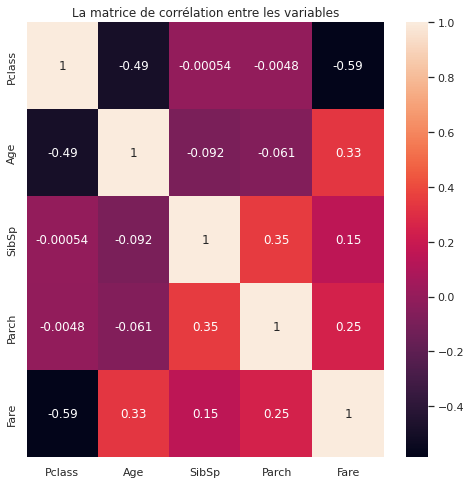

```python
# plot a heatmap with annotation
corr_df = numerical_data.corr(method='pearson')

plt.figure(figsize=(8, 8))
sns.heatmap(corr_df, annot=True)
plt.title('La matrice de corrélation entre les variables')
plt.show()
```

*=>* On constate que la corrélation entre les varibales `Age`<=>`Pclass` est négative  
*=>* On constate que la corrélation entre les varibales `Pclass`<=>`Fare` est négative

*=>* Pour le reste des corrélations entre les variables, la corrélation varie entre corrélation faible et moyenne.

- **Centrer et Réduire les données :**

```python
#importer les packages nécessaires
from sklearn.preprocessing import StandardScaler
```

```python
# séparer les features et le target
#features
X = numerical_data
# Separating out the target
y = data[['Survived']]
# Standardizing the features
X_sc = StandardScaler().fit_transform(X)
# convertir les données en DataFrame
X_sc = pd.DataFrame(X_sc , columns = X.columns)
```

```python
#vérification
X_sc
```

|  | Pclass | Age | SibSp | Parch | Fare |
| --- | --- | --- | --- | --- | --- |
| 0 | 1.012325 | 0.298549 | -0.552184 | -0.491199 | -0.541515 |
| 1 | 1.012325 | 1.181328 | 0.593598 | -0.491199 | -0.555094 |
| 2 | -0.171097 | 2.240662 | -0.552184 | -0.491199 | -0.511083 |
| 3 | 1.012325 | -0.231118 | -0.552184 | -0.491199 | -0.527868 |
| 4 | 1.012325 | -0.584229 | 0.593598 | 0.744240 | -0.468504 |
| ... | ... | ... | ... | ... | ... |
| 327 | 1.012325 | -1.926053 | 0.593598 | 0.744240 | -0.444144 |
| 328 | -1.354519 | 0.475105 | 0.593598 | -0.491199 | 0.804139 |
| 329 | 1.012325 | -0.160496 | -0.552184 | -0.491199 | -0.542402 |
| 330 | -1.354519 | 0.616350 | -0.552184 | -0.491199 | 1.113651 |
| 331 | 1.012325 | 0.581038 | -0.552184 | -0.491199 | -0.551000 |

332 rows × 5 columns

- **Appliquer l'ACP :**

```python
#importer les packages
from sklearn.decomposition import PCA
#fixer le nombre de composantes en 2
pca = PCA(n_components=2)
#ajustement
principalComponents = pca.fit_transform(X_sc)
```

```python
#vérifier les données
principalDf = pd.DataFrame(data = principalComponents
             , columns = ['composante principale 1', 'composante principale 2'])
principalDf
```

|  | composante principale 1 | composante principale 2 |
| --- | --- | --- |
| 0 | -0.927192 | -0.682985 |
| 1 | -0.380706 | -0.216498 |
| 2 | 0.765037 | -1.487213 |
| 3 | -1.179411 | -0.514033 |
| 4 | -0.998422 | 1.161841 |
| ... | ... | ... |
| 327 | -1.643432 | 1.588449 |
| 328 | 1.517669 | -0.198222 |
| 329 | -1.153321 | -0.538310 |
| 330 | 1.649943 | -0.946975 |
| 331 | -0.793984 | -0.773397 |

332 rows × 2 columns

```python
#Ajout de la variable target
finalDf = pd.concat([principalDf, y], axis = 1)
```

```python
#verification
finalDf
```

|  | composante principale 1 | composante principale 2 | Survived |
| --- | --- | --- | --- |
| 0 | -0.927192 | -0.682985 | 0 |
| 1 | -0.380706 | -0.216498 | 1 |
| 2 | 0.765037 | -1.487213 | 0 |
| 3 | -1.179411 | -0.514033 | 0 |
| 4 | -0.998422 | 1.161841 | 1 |
| ... | ... | ... | ... |
| 327 | -1.643432 | 1.588449 | 1 |
| 328 | 1.517669 | -0.198222 | 1 |
| 329 | -1.153321 | -0.538310 | 1 |
| 330 | 1.649943 | -0.946975 | 1 |
| 331 | -0.793984 | -0.773397 | 0 |

332 rows × 3 columns

```python
# Le pourcentage d'informations garantie par chaque composante
pca.explained_variance_ratio_
```

```
array([0.39410368, 0.28590355])
```

*=>* On constate que la première composante contient `39.41%` d'informations tandis que la deuxième a `28.59%` d'informations ce qui donne `68%` d'informations dans le nouveau espace

- *La visualisation des componsantes (ACP) :*
1. **Avec Python** :

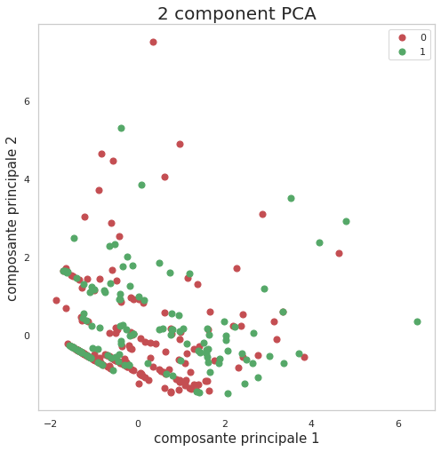

```python
# ajuster les dimensions de la fenetre
fig = plt.figure(figsize = (8,8))
# ajouter les sous-plot
ax = fig.subplots(1,1)
# Labeliser les axes
ax.set_xlabel('composante principale 1', fontsize = 15)
ax.set_ylabel('composante principale 2', fontsize = 15)
# ajout du titre
ax.set_title('2 component PCA', fontsize = 20)
# la variable contenant les valeurs du target
targets = [0,1]
# couleurs des plots
colors = ['r', 'g']
# processus
for target, color in zip(targets,colors):
    indicesToKeep = finalDf['Survived'] == target
    ax.scatter(finalDf.loc[indicesToKeep, 'composante principale 1']
               , finalDf.loc[indicesToKeep, 'composante principale 2']
               , c = color
               , s = 50)
ax.legend(targets)
ax.grid()
```

1. **Avec R** :

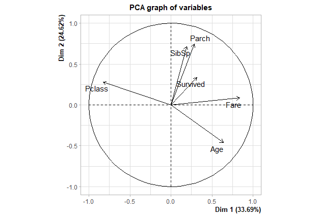

*=>* On constate que la corrélation entre les varibales `Age`<=>`Pclass` est négative

*=>* Les varibales `Age`<=>`Parch` sont indépendantes

*=>* Les varibales `Survived`<=>`Age` sont indépendantes

### **2. AFC :**

```python
# on va prendre une copie du dataset pour réaliser l'AFC
afc_data = data[['Sex', 'Embarked', 'Pclass', 'Age','Survived']]
```

```python
# vérification
afc_data.head()
```

|  | Sex | Embarked | Pclass | Age | Survived |
| --- | --- | --- | --- | --- | --- |
| 0 | male | Q | 3 | 34.5 | 0 |
| 1 | female | S | 3 | 47.0 | 1 |
| 2 | male | Q | 2 | 62.0 | 0 |
| 3 | male | S | 3 | 27.0 | 0 |
| 4 | female | S | 3 | 22.0 | 1 |

- **Comme la variable `Age` a plusieurs valeurs, on va les grouper selon des intervalles `bins`, pour mieux voir les données** :

```python
afc_data['Age'].describe().to_frame()
```

|  | Age |
| --- | --- |
| count | 332.000000 |
| mean | 30.272590 |
| std | 14.181209 |
| min | 0.170000 |
| 25% | 21.000000 |
| 50% | 27.000000 |
| 75% | 39.000000 |
| max | 76.000000 |

```python
# dévision des valeurs de 'Age'
afc_data['Age_bin'] = pd.cut(afc_data['Age'],
                         [0, 21, 27, 39, 76])
```

```python
# affichage
afc_data['Age_bin'].value_counts().sort_index()
```

```
(0, 21]     86
(21, 27]    81
(27, 39]    83
(39, 76]    82
Name: Age_bin, dtype: int64
```

- **Comme la variable `Pclass` a plusieurs valeurs(1,2,3...), on va les rendre qualitatives(first,second,third...)** :

```python
# voir les modalités de la variables 'Pclass'
afc_data['Pclass'].value_counts().sort_index()
```

```
1     98
2     88
3    146
Name: Pclass, dtype: int64
```

```python
# rendre la variable qualitative
afc_data['Pclass'].replace([1,2,3],['first','second','third'] , inplace=True)
```

```python
# vérification
afc_data['Pclass'].value_counts().sort_index()
```

```
first      98
second     88
third     146
Name: Pclass, dtype: int64
```

- **Comme la variable `Survived` a deux valeurs(0,1), on va les rendre qualitatives(survived,not survived)** :

```python
# voir les modalités de la variables 'Survived'
afc_data['Survived'].value_counts().sort_index()
```

```
0    205
1    127
Name: Survived, dtype: int64
```

```python
# rendre la variable qualitative
afc_data['Survived'].replace([0,1],['not survived','survived'] , inplace=True)
```

```python
# vérification
afc_data['Survived'].value_counts().sort_index()
```

```
not survived    205
survived        127
Name: Survived, dtype: int64
```

- **Appliquer l'AFC** :

```python
afc_data.head()
```

|  | Sex | Embarked | Pclass | Age | Survived | Age_bin |
| --- | --- | --- | --- | --- | --- | --- |
| 0 | male | Q | third | 34.5 | not survived | (27, 39] |
| 1 | female | S | third | 47.0 | survived | (39, 76] |
| 2 | male | Q | second | 62.0 | not survived | (39, 76] |
| 3 | male | S | third | 27.0 | not survived | (21, 27] |
| 4 | female | S | third | 22.0 | survived | (21, 27] |

```python
!pip install prince
```

```python
#importer le package nécessaire
import prince

#prendre le dataset
afc_data = afc_data[['Sex', 'Embarked', 'Pclass', 'Age_bin','Survived']]

#instancier le model
mca = prince.MCA()
mca.fit(afc_data)
```

```
MCA()
```

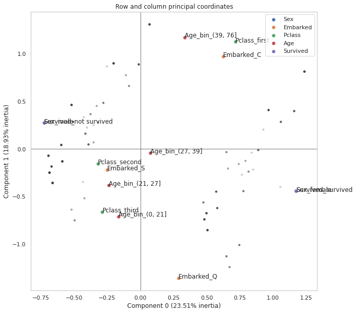

```python
# voir le graph
mca.plot_coordinates(afc_data,
                     row_points_alpha=.2,
                     figsize=(10, 10),
                     show_column_labels=True
                    )
```

*=>* Le genre des gens survivant est `female` car la distance entre les points qui représentent ces entités est trop petite, tandis que les gens non-survivant sont en général des `male` .

*=>* Les gens dont l'`age` est compris entre 39 et 76 dominent la première classe dont le point de départ est `C` .

*=>* Les gens dont le points de départ est `S` ont choisi la `2ème classe` .

*=>* On constate aussi que la variable `Age` n'a pas de corrélation avec la variable `Survived` .

### **3. Classification K-mean**

```python
# prendre une copie du dataset
data_class = data.copy()
```

```python
# vérification
data_class.head()
```

|  | PassengerId | Survived | Pclass | Name | Sex | Age | SibSp | Parch | Ticket | Fare | Embarked |
| --- | --- | --- | --- | --- | --- | --- | --- | --- | --- | --- | --- |
| 0 | 892 | 0 | 3 | Kelly, Mr. James | male | 34.5 | 0 | 0 | 330911 | 7.8292 | Q |
| 1 | 893 | 1 | 3 | Wilkes, Mrs. James (Ellen Needs) | female | 47.0 | 1 | 0 | 363272 | 7.0000 | S |
| 2 | 894 | 0 | 2 | Myles, Mr. Thomas Francis | male | 62.0 | 0 | 0 | 240276 | 9.6875 | Q |
| 3 | 895 | 0 | 3 | Wirz, Mr. Albert | male | 27.0 | 0 | 0 | 315154 | 8.6625 | S |
| 4 | 896 | 1 | 3 | Hirvonen, Mrs. Alexander (Helga E Lindqvist) | female | 22.0 | 1 | 1 | 3101298 | 12.2875 | S |

```python
# rendre la variable "Sex" quatitative
data_class['Sex'].replace(['male','female'], [1,0] , inplace=True)
```

```python
# rendre la variable "Embarked" quatitative
data_class['Embarked'].replace(['S','C','Q'], [0,1,2] , inplace=True)
```

```python
data_class = data_class[['Survived','Pclass','Sex', 'Age','SibSp','Parch','Fare','Embarked']]
data_class
```

|  | Survived | Pclass | Sex | Age | SibSp | Parch | Fare | Embarked |
| --- | --- | --- | --- | --- | --- | --- | --- | --- |
| 0 | 0 | 3 | 1 | 34.5 | 0 | 0 | 7.8292 | 2 |
| 1 | 1 | 3 | 0 | 47.0 | 1 | 0 | 7.0000 | 0 |
| 2 | 0 | 2 | 1 | 62.0 | 0 | 0 | 9.6875 | 2 |
| 3 | 0 | 3 | 1 | 27.0 | 0 | 0 | 8.6625 | 0 |
| 4 | 1 | 3 | 0 | 22.0 | 1 | 1 | 12.2875 | 0 |
| ... | ... | ... | ... | ... | ... | ... | ... | ... |
| 327 | 1 | 3 | 0 | 3.0 | 1 | 1 | 13.7750 | 0 |
| 328 | 1 | 1 | 0 | 37.0 | 1 | 0 | 90.0000 | 2 |
| 329 | 1 | 3 | 0 | 28.0 | 0 | 0 | 7.7750 | 0 |
| 330 | 1 | 1 | 0 | 39.0 | 0 | 0 | 108.9000 | 1 |
| 331 | 0 | 3 | 1 | 38.5 | 0 | 0 | 7.2500 | 0 |

332 rows × 8 columns

```python
# import package
from sklearn.cluster import KMeans
```

[figure not shown]

```python
#Application de KMeans
kmeans = KMeans(n_clusters=2)
kmeans.fit(data_class)

#Visualisation
colormap=np.array(["red", "green"])
plt.scatter(data_class.Age, data_class.Fare, c=colormap[kmeans.labels_], s=20)
plt.legend(['Not Survived'])
plt.title('La classification des variables Par K-means', fontsize=14, fontweight='bold')
plt.xlabel('Age', fontweight='bold')
plt.ylabel('Fare',  fontweight='bold')
plt.show()
```

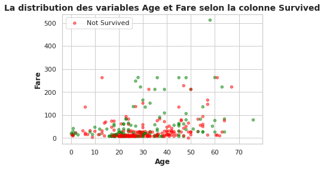

```python
plt.scatter(data_class.Age, data_class.Fare, c=colormap[data_class.Survived], s=20, alpha=.5)
plt.legend(['Not Survived'])
plt.title('La distribution des variables Age et Fare selon la colonne Survived', fontsize=14, fontweight='bold')
plt.xlabel('Age', fontweight='bold')
plt.ylabel('Fare',  fontweight='bold')
plt.show()
```

### **Conclusion**

On peut conclure aussi que le facteur `Age` ne peut pas affirmer si la personne va survivre ou non

### **Références**

- [Le data set](https://www.kaggle.com/datasets/brendan45774/test-file)
- [ACP](https://towardsdatascience.com/pca-using-python-scikit-learn-e653f8989e60)
- [AFC](https://www.tibco.com/reference-center/what-is-correspondence-analysis#:~:text=Correspondence%20analysis%2C%20also%20called%20reciprocal,two%20or%20more%20data%20points)
- Cours analyse de données